# Análisis evolución Covid-19 Chile casos y decesos (23/04/2020)

Claudio Bustos

23/4/2020

- Reportes anteriores: https://github.com/clbustos/analisis_covid19_chile

## Análisis de series de casos

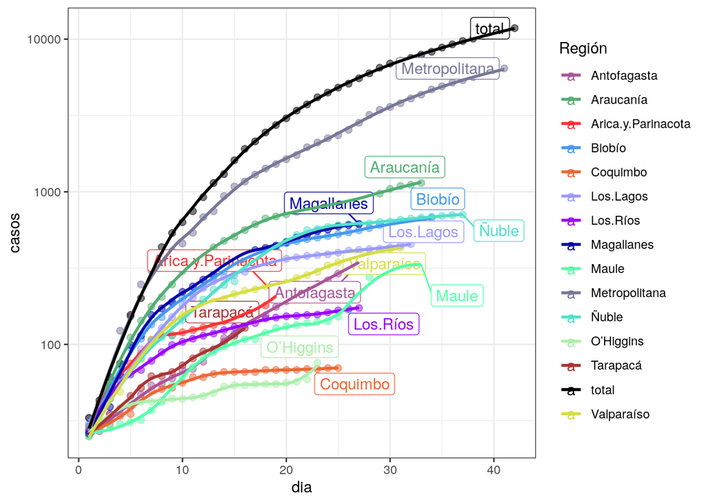

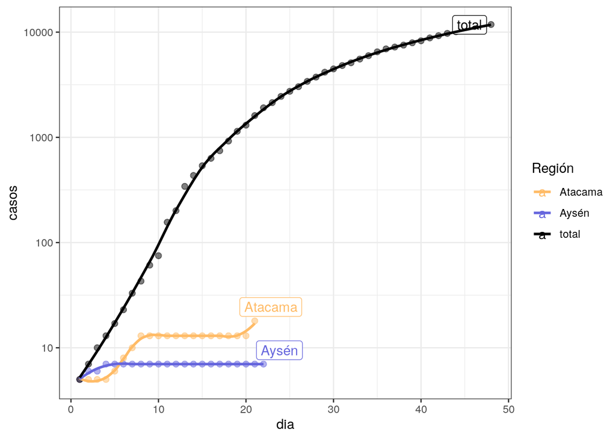

La serie por región se hace partir de los 5 primeros casos.

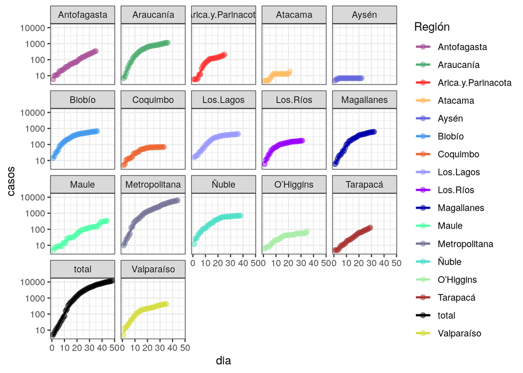

Con respecto a la serie de casos totales de día vs el anterior, se mantiene constante desde hace días una tasa de incremento diario de 10% para casi todo el Norte Grande: Arica y Parinacota, Tarapacá y Antofagasta.

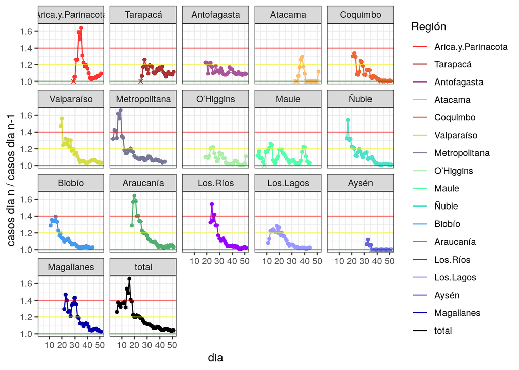

En la serie de casos nuevos diarios vs los del día anterior, con ventana de 7 días, se puede apreciar un decremento en Valparaíso, Metropolitana, Ñuble y Araucanía. Biobío está estabilizado en 1, al igual que los Ríos y Los Lagos. La serie total desde aproximadamente una semana muestra una tedencia a la estabilización.

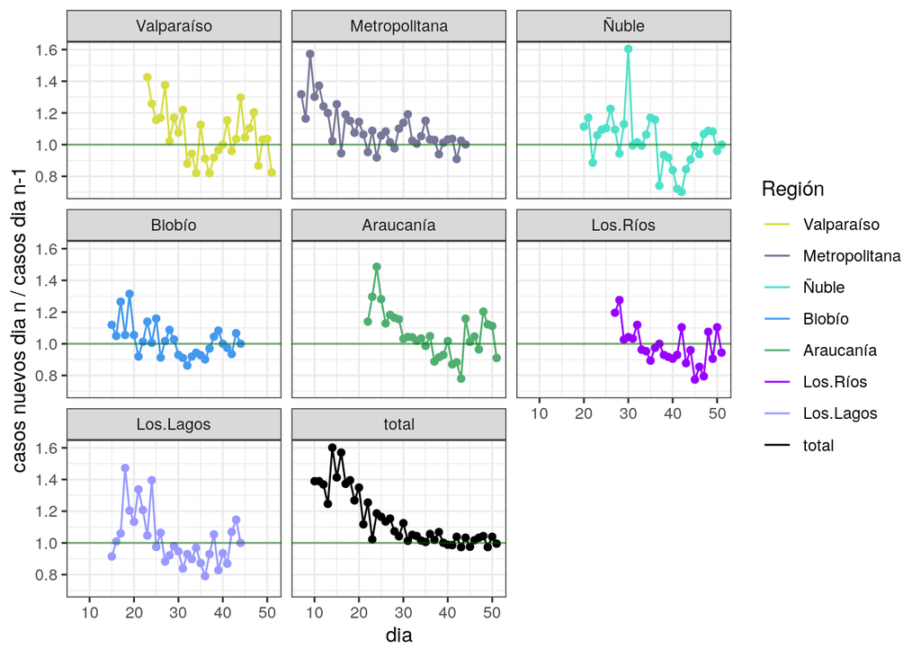

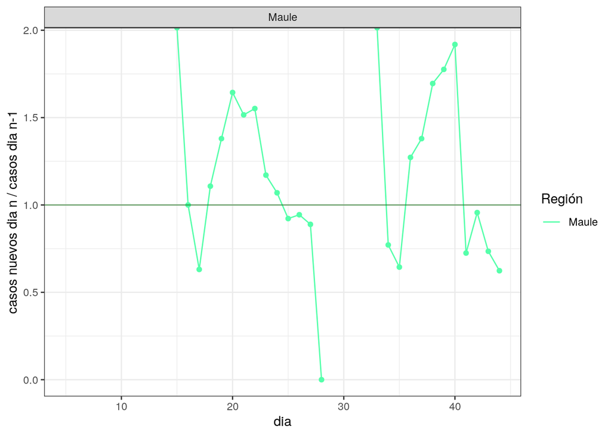

## Predicción

### Predicción para serie total

Recordemos que la regresión exponencial se eliminó, porque ya no calza con la serie total. El informe de la semana pasada mostró una subestimación constante de los modelos AR(1) + AR(4), y sobreestimación (lo que sabíamos), del modelo ARIMA. . Este último modelo se eliminará, ya que si bien los intervalos de confianza se cumplen, siempre sobreestima. A partir del análisis del resultado del algoritmo de la última semana, para la predicción total se recorta la serie a partir de lo 50 casos.

Se cambio el día de referencia al modelo del día 16, para realizar mañana el análisis del modelo cuadrático con propiedades. Si observamos la predicción a 7 días plazo, podemos ver que nuevamente el modelo cuadrático sobreestima el valor observado, en tanto que T+AR(1) y T+AR(4) subestima. Todas las predicciones presentan intervalos correctos, excepto el límite inferior del cuadrático.

|  | casos | li | ls |
| --- | --- | --- | --- |
| **Observado** | 11812 | NA | NA |
| **General: Cuadrático + AR(2)** | 12776 | 12503 | 13049 |
| **Casos nuevos : Tendencia + AR(1)** | 10457 | 9658 | 12008 |
| **Casos nuevos: Tendencia + AR(4)** | 10393 | 9626 | 11916 |

Como ha sido la tónica durante la semana, el modelo cuadrático es el más pesimista, pero los modelos T+AR(1) y T+AR(4) tienden a converger. En una semana deberíamos tener entre 13500 y 15810 casos.

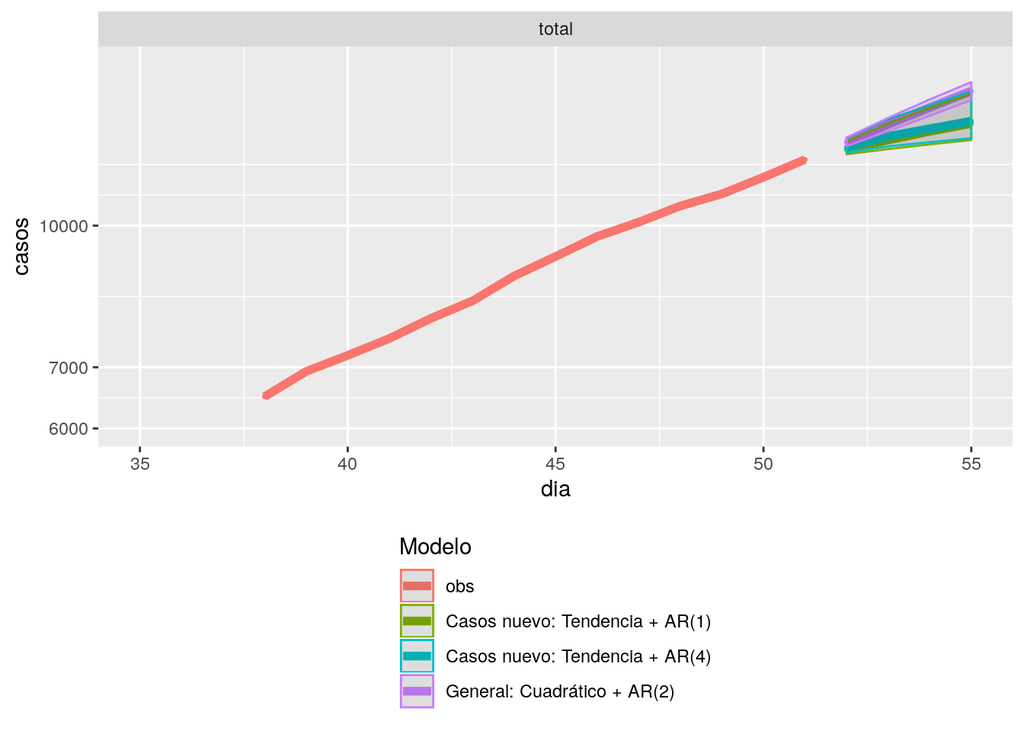

Casos nuevos: tendencia + AR(4) : total

|  | dia | casos | li | ls |
| --- | --- | --- | --- | --- |
| **41** | 52 | 12186 | 12022 | 12479 |
| **42** | 53 | 12520 | 12209 | 13074 |
| **43** | 54 | 12766 | 12339 | 13538 |
| **44** | 55 | 13010 | 12462 | 14024 |
| **45** | 56 | 13224 | 12570 | 14449 |
| **46** | 57 | 13448 | 12678 | 14911 |
| **47** | 58 | 13646 | 12773 | 15323 |

Casos nuevos: tendencia + AR(1) : total

|  | dia | casos | li | ls |
| --- | --- | --- | --- | --- |
| **41** | 52 | 12106 | 11969 | 12364 |
| **42** | 53 | 12406 | 12127 | 12932 |
| **43** | 54 | 12680 | 12272 | 13452 |
| **44** | 55 | 12934 | 12406 | 13933 |
| **45** | 56 | 13167 | 12529 | 14375 |
| **46** | 57 | 13380 | 12641 | 14778 |
| **47** | 58 | 13573 | 12743 | 15144 |

General: Modelo cuadrático : total

|  | dia | casos | li | ls |
| --- | --- | --- | --- | --- |
| **41** | 52 | 12350 | 12218 | 12482 |
| **42** | 53 | 12902 | 12686 | 13118 |
| **43** | 54 | 13465 | 13189 | 13741 |
| **44** | 55 | 14037 | 13719 | 14356 |
| **45** | 56 | 14619 | 14271 | 14967 |
| **46** | 57 | 15210 | 14842 | 15578 |
| **47** | 58 | 15810 | 15428 | 16193 |

### Predicciones para serie total usando predicción por regiones.

Otro modelo posible de análisis es usar la suma de las predicciones parciales por región. No he calculado los intervalos de confianza, porque para que sean adecuados debería considerar la covarianza entre las series de las distintas regiones.

Durante la semana se ha visto que la predicción del método cuadrático y el de tendencia de casos nuevos comienza a converger, lo cual suele ocurrir cuando las tasas locales dejan de tener variaciones bruscas. Este modelo predice entre 14700 y 15500 casos en una semana.

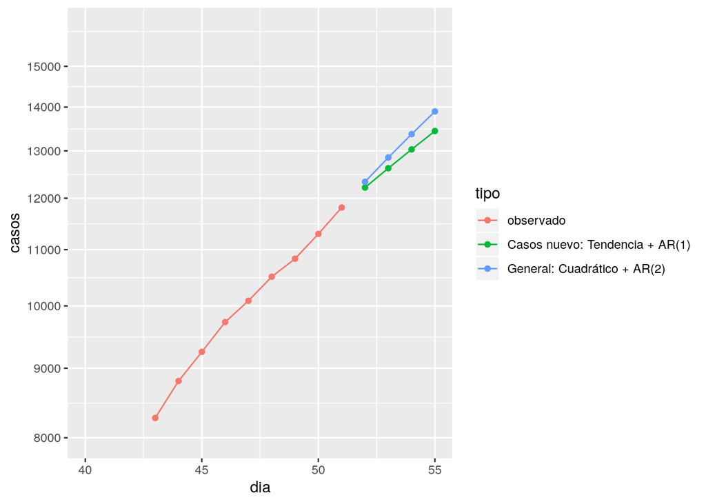

| dia | fecha | tipo | casos |
| --- | --- | --- | --- |
| 1 | 43893 | observado | 1 |
| 2 | 43894 | observado | 3 |
| 3 | 43895 | observado | 4 |
| 4 | 43896 | observado | 5 |
| 5 | 43897 | observado | 7 |
| 6 | 43898 | observado | 10 |
| 7 | 43899 | observado | 13 |
| 8 | 43900 | observado | 17 |
| 9 | 43901 | observado | 23 |
| 10 | 43902 | observado | 33 |
| 11 | 43903 | observado | 43 |
| 12 | 43904 | observado | 61 |
| 13 | 43905 | observado | 75 |
| 14 | 43906 | observado | 156 |
| 15 | 43907 | observado | 201 |
| 16 | 43908 | observado | 342 |
| 17 | 43909 | observado | 434 |
| 18 | 43910 | observado | 537 |
| 19 | 43911 | observado | 632 |
| 20 | 43912 | observado | 746 |
| 21 | 43913 | observado | 922 |
| 22 | 43914 | observado | 1142 |
| 23 | 43915 | observado | 1306 |
| 24 | 43916 | observado | 1610 |
| 25 | 43917 | observado | 1909 |
| 26 | 43918 | observado | 2139 |
| 27 | 43919 | observado | 2449 |
| 28 | 43920 | observado | 2738 |
| 29 | 43921 | observado | 3031 |
| 30 | 43922 | observado | 3404 |
| 31 | 43923 | observado | 3737 |
| 32 | 43924 | observado | 4161 |
| 33 | 43925 | observado | 4471 |
| 34 | 43926 | observado | 4815 |
| 35 | 43927 | observado | 5116 |
| 36 | 43928 | observado | 5546 |
| 37 | 43929 | observado | 5972 |
| 38 | 43930 | observado | 6501 |
| 39 | 43931 | observado | 6927 |
| 40 | 43932 | observado | 7213 |
| 41 | 43933 | observado | 7525 |
| 42 | 43934 | observado | 7917 |
| 43 | 43935 | observado | 8273 |
| 44 | 43936 | observado | 8807 |
| 45 | 43937 | observado | 9252 |
| 46 | 43938 | observado | 9730 |
| 47 | 43939 | observado | 10088 |
| 48 | 43940 | observado | 10507 |
| 49 | 43941 | observado | 10832 |
| 50 | 43942 | observado | 11296 |
| 51 | 43943 | observado | 11812 |
| 52 | 43944 | Casos nuevo: Tendencia + AR(1) | 12218 |
| 53 | 43945 | Casos nuevo: Tendencia + AR(1) | 12624 |
| 54 | 43946 | Casos nuevo: Tendencia + AR(1) | 13032 |
| 55 | 43947 | Casos nuevo: Tendencia + AR(1) | 13444 |
| 56 | 43948 | Casos nuevo: Tendencia + AR(1) | 13861 |
| 57 | 43949 | Casos nuevo: Tendencia + AR(1) | 14285 |
| 58 | 43950 | Casos nuevo: Tendencia + AR(1) | 14718 |
| 52 | 43944 | General: Cuadrático + AR(2) | 12337 |
| 53 | 43945 | General: Cuadrático + AR(2) | 12855 |
| 54 | 43946 | General: Cuadrático + AR(2) | 13373 |
| 55 | 43947 | General: Cuadrático + AR(2) | 13897 |
| 56 | 43948 | General: Cuadrático + AR(2) | 14431 |
| 57 | 43949 | General: Cuadrático + AR(2) | 14976 |
| 58 | 43950 | General: Cuadrático + AR(2) | 15529 |

### Predicción por regiones

Eliminaremos la predicción de Atacama y Aysén, que presentan tasas estabilizadas.

Se debe observar el intervalo de confianza superior elevado en Arica y Parinacota, así como el de Antofagasta y O’Higgins, debido a los cambios recientes en tasas. Recordemos que el algoritmo inicia desde 10 casos en cada Región.

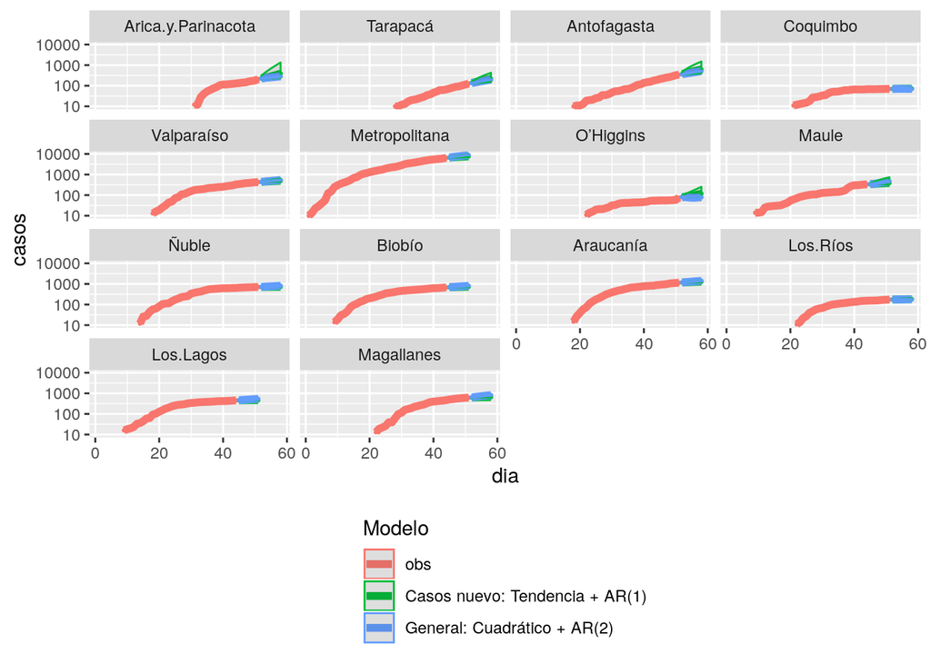

Las tablas por regiones se incluye en el Anexo I

## Ventiladores y Casos en UCI

Una primera serie es la de ventiladores disponibles. Se aprecia un aumento de 24 ventiladores entre ayer y hoy, debido principalmente a que se han dejado de ocupar.

Uso de ventiladores última semana

| fecha | total | disponibles | ocupados |
| --- | --- | --- | --- |
| 2020-04-16 | 1582 | 569 | 1013 |
| 2020-04-17 | 1604 | 579 | 1025 |
| 2020-04-18 | 1627 | 588 | 1039 |
| 2020-04-19 | 1627 | 570 | 1057 |
| 2020-04-20 | 1621 | 538 | 1083 |
| 2020-04-21 | 1614 | 521 | 1093 |
| 2020-04-22 | 1619 | 545 | 1074 |

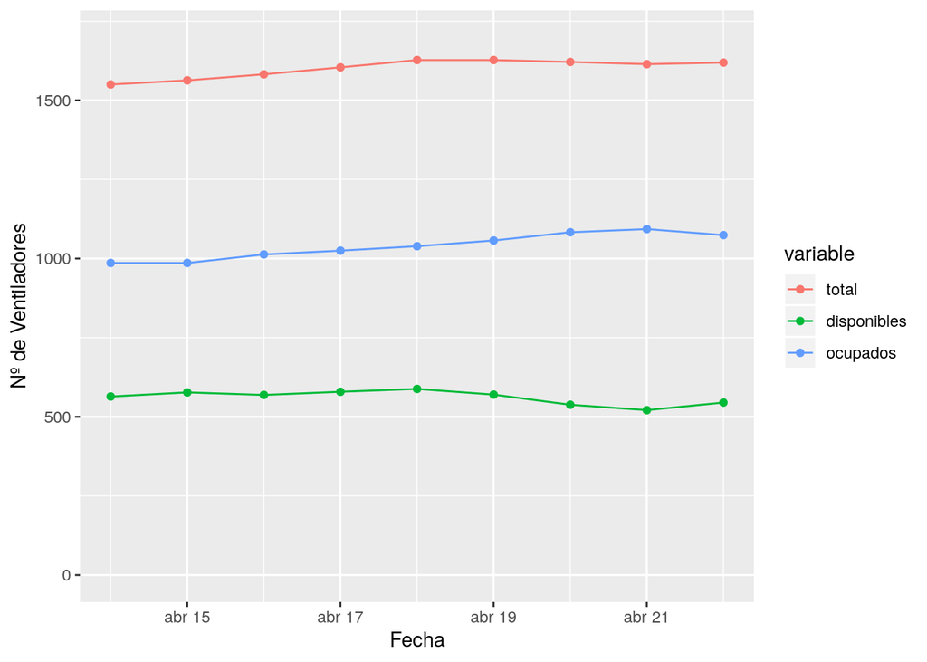

Si analizamos la serie total de pacientes en UCI para Covid-19, podemos ver un nuevo máximo en la serie con 399 casos

Uso de camas UCI Covid-19

| fecha | total |
| --- | --- |
| 2020-04-16 | 384 |
| 2020-04-17 | 385 |
| 2020-04-18 | 360 |
| 2020-04-19 | 373 |
| 2020-04-20 | 377 |
| 2020-04-21 | 392 |
| 2020-04-22 | 399 |

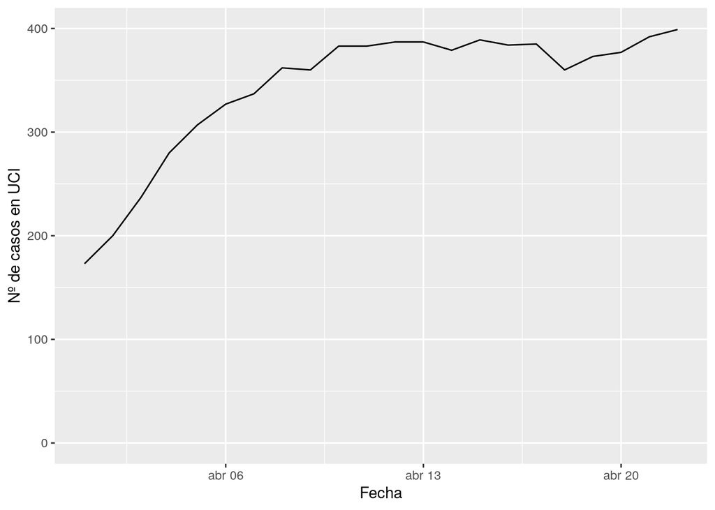

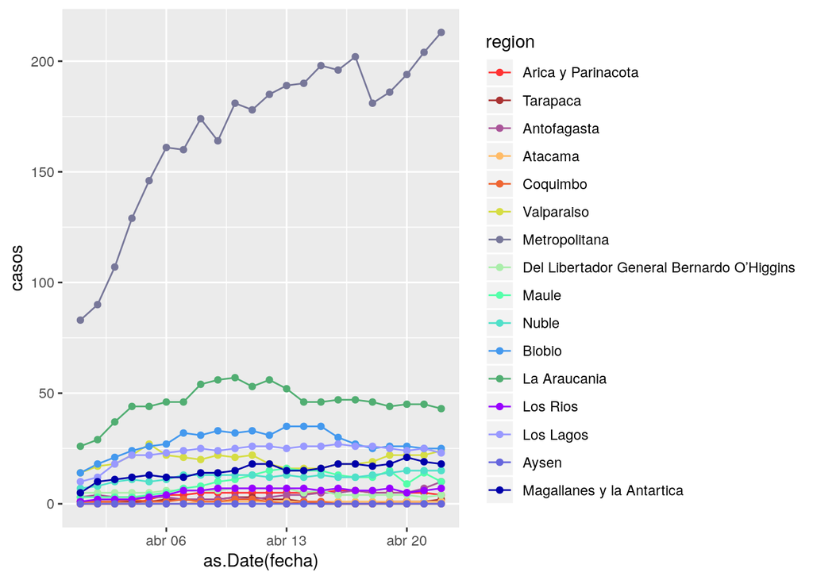

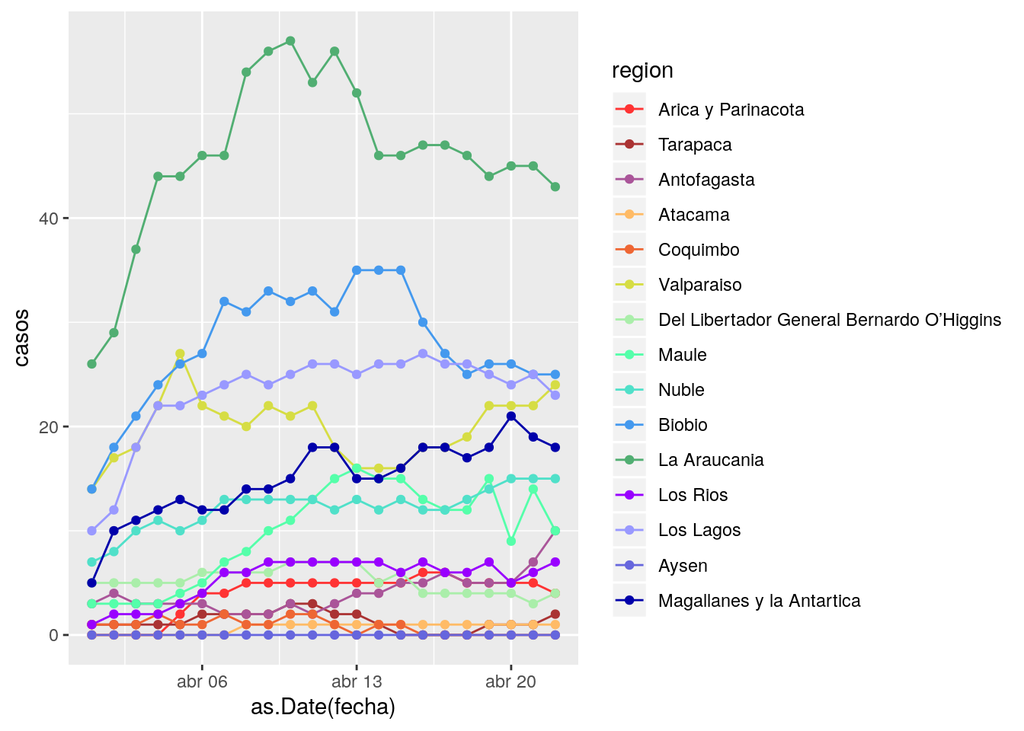

## Decesos

Si observamos la serie total de decesos, observamos una tasa relativamente constante en los últimos 9 días, atribuible a la región Metropolitana, ya que el resto de las series muestra menor cantidad de casos.

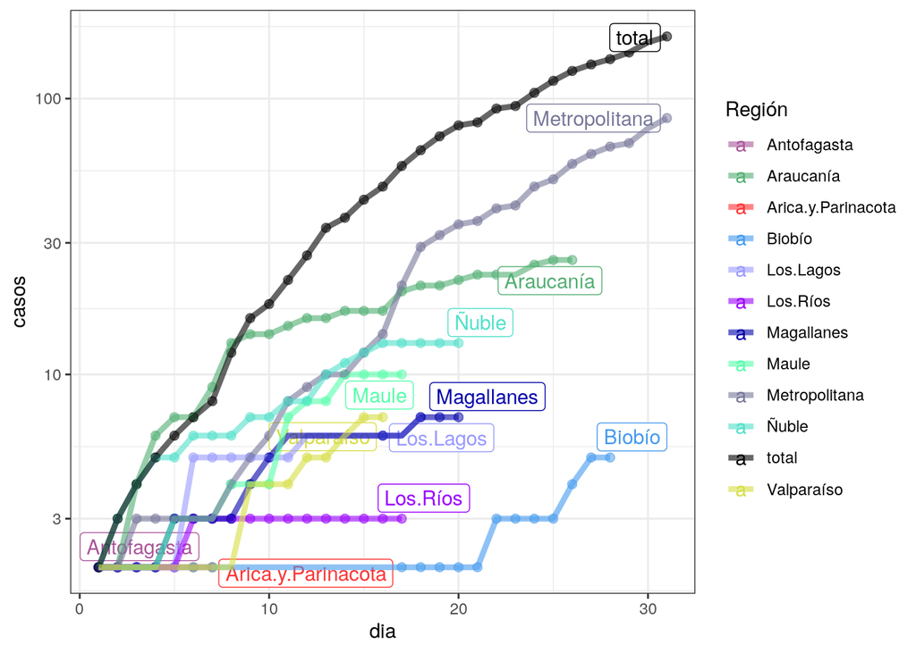

**Fuentes de información**: Principalmente, se utilizó el reporte diario del [MINSAL](https://www.minsal.cl/nuevo-coronavirus-2019-ncov/casos-confirmados-en-chile-covid-19/), usando [Wayback machine](https://archive.org/web/) para recopilar la información ya no disponible. También se ocupa la nueva serie disponible en el [Github del Ministerio de Ciencias](https://github.com/MinCiencia/Datos-COVID19).

## Anexo I: Predicciones por región

Casos nuevos: tendencia + AR(1) : Arica.y.Parinacota

|  | dia | casos | li | ls |
| --- | --- | --- | --- | --- |
| **22** | 52 | 225.7 | 212.5 | 308.7 |
| **23** | 53 | 242.7 | 215.2 | 416.4 |
| **24** | 54 | 262.4 | 218.3 | 541.8 |
| **25** | 55 | 285.9 | 222 | 690.3 |
| **26** | 56 | 313.9 | 226.4 | 868.3 |
| **27** | 57 | 347.9 | 231.8 | 1084 |
| **28** | 58 | 389.6 | 238.3 | 1348 |

Casos nuevos: tendencia + AR(1) : Tarapacá

|  | dia | casos | li | ls |
| --- | --- | --- | --- | --- |
| **25** | 52 | 137.6 | 130.9 | 160.2 |
| **26** | 53 | 148.7 | 134.1 | 198.2 |
| **27** | 54 | 160.4 | 137.6 | 238.2 |
| **28** | 55 | 173 | 141.2 | 280.9 |
| **29** | 56 | 186.3 | 145.1 | 326.4 |
| **30** | 57 | 200.4 | 149.3 | 374.8 |
| **31** | 58 | 215.5 | 153.7 | 426.1 |

Casos nuevos: tendencia + AR(1) : Antofagasta

|  | dia | casos | li | ls |
| --- | --- | --- | --- | --- |
| **35** | 52 | 375.1 | 348.8 | 480.2 |
| **36** | 53 | 406.4 | 356.3 | 610.5 |
| **37** | 54 | 442.3 | 364.9 | 760.1 |
| **38** | 55 | 480.9 | 374.2 | 921.5 |
| **39** | 56 | 523.2 | 384.3 | 1098 |
| **40** | 57 | 569.2 | 395.4 | 1290 |
| **41** | 58 | 619.4 | 407.4 | 1499 |

Casos nuevos: tendencia + AR(1) : Coquimbo

|  | dia | casos | li | ls |
| --- | --- | --- | --- | --- |
| **32** | 52 | 70.55 | 70.14 | 72.08 |
| **33** | 53 | 71.02 | 70.27 | 73.9 |
| **34** | 54 | 71.43 | 70.37 | 75.44 |
| **35** | 55 | 71.76 | 70.46 | 76.72 |
| **36** | 56 | 72.04 | 70.54 | 77.79 |
| **37** | 57 | 72.27 | 70.6 | 78.67 |
| **38** | 58 | 72.46 | 70.65 | 79.39 |

Casos nuevos: tendencia + AR(1) : Valparaíso

|  | dia | casos | li | ls |
| --- | --- | --- | --- | --- |
| **35** | 52 | 439.6 | 432.4 | 461.5 |
| **36** | 53 | 449.9 | 435.8 | 493.4 |
| **37** | 54 | 459.8 | 439 | 523.8 |
| **38** | 55 | 469.1 | 442 | 552.8 |
| **39** | 56 | 478 | 444.9 | 580.2 |
| **40** | 57 | 486.4 | 447.6 | 606 |
| **41** | 58 | 494.2 | 450.1 | 630.3 |

Casos nuevos: tendencia + AR(1) : Metropolitana

|  | dia | casos | li | ls |
| --- | --- | --- | --- | --- |
| **45** | 45 | 6656 | 6527 | 6966 |
| **46** | 46 | 6846 | 6604 | 7433 |
| **47** | 47 | 7020 | 6675 | 7859 |
| **48** | 48 | 7180 | 6740 | 8254 |
| **49** | 49 | 7328 | 6800 | 8618 |
| **50** | 50 | 7464 | 6855 | 8952 |
| **51** | 51 | 7588 | 6906 | 9256 |

Casos nuevos: tendencia + AR(1) : O’Higgins

|  | dia | casos | li | ls |
| --- | --- | --- | --- | --- |
| **31** | 52 | 80.96 | 77.19 | 96.64 |
| **32** | 53 | 85.13 | 78.16 | 114.6 |
| **33** | 54 | 89.62 | 79.2 | 134.1 |
| **34** | 55 | 94.81 | 80.4 | 156.5 |
| **35** | 56 | 100.9 | 81.81 | 183.1 |
| **36** | 57 | 108.3 | 83.5 | 214.7 |
| **37** | 58 | 117.1 | 85.54 | 253 |

Casos nuevos: tendencia + AR(1) : Maule

|  | dia | casos | li | ls |
| --- | --- | --- | --- | --- |
| **37** | 45 | 340.1 | 334.1 | 378.9 |
| **38** | 46 | 348 | 335.2 | 437.1 |
| **39** | 47 | 356.2 | 336.3 | 498.1 |
| **40** | 48 | 364.4 | 337.4 | 559.1 |
| **41** | 49 | 372.5 | 338.5 | 619.2 |
| **42** | 50 | 380.4 | 339.5 | 677.9 |
| **43** | 51 | 388 | 340.5 | 734.9 |

Casos nuevos: tendencia + AR(1) : Ñuble

|  | dia | casos | li | ls |
| --- | --- | --- | --- | --- |
| **39** | 52 | 711.9 | 708.9 | 723.9 |
| **40** | 53 | 715 | 709.7 | 737.2 |
| **41** | 54 | 717.7 | 710.3 | 748.2 |
| **42** | 55 | 719.9 | 710.9 | 757.2 |
| **43** | 56 | 721.6 | 711.3 | 764.6 |
| **44** | 57 | 723.1 | 711.6 | 770.6 |
| **45** | 58 | 724.2 | 711.9 | 775.4 |

Casos nuevos: tendencia + AR(1) : Biobío

|  | dia | casos | li | ls |
| --- | --- | --- | --- | --- |
| **37** | 45 | 685.8 | 679.7 | 700.1 |
| **38** | 46 | 694.8 | 683.5 | 721.4 |
| **39** | 47 | 702.8 | 686.8 | 740.2 |
| **40** | 48 | 709.8 | 689.8 | 756.9 |
| **41** | 49 | 716.1 | 692.4 | 771.7 |
| **42** | 50 | 721.6 | 694.8 | 784.8 |
| **43** | 51 | 726.4 | 696.8 | 796.3 |

Casos nuevos: tendencia + AR(1) : Araucanía

|  | dia | casos | li | ls |
| --- | --- | --- | --- | --- |
| **35** | 52 | 1166 | 1152 | 1201 |
| **36** | 53 | 1188 | 1161 | 1256 |
| **37** | 54 | 1208 | 1169 | 1307 |
| **38** | 55 | 1227 | 1176 | 1354 |
| **39** | 56 | 1244 | 1183 | 1397 |
| **40** | 57 | 1260 | 1189 | 1436 |
| **41** | 58 | 1274 | 1195 | 1472 |

Casos nuevos: tendencia + AR(1) : Los.Ríos

|  | dia | casos | li | ls |
| --- | --- | --- | --- | --- |
| **31** | 52 | 174.8 | 173.6 | 178.4 |
| **32** | 53 | 176.4 | 174.1 | 183.4 |
| **33** | 54 | 177.9 | 174.6 | 187.8 |
| **34** | 55 | 179.2 | 175 | 191.8 |
| **35** | 56 | 180.3 | 175.4 | 195.3 |
| **36** | 57 | 181.4 | 175.8 | 198.5 |
| **37** | 58 | 182.3 | 176.1 | 201.3 |

Casos nuevos: tendencia + AR(1) : Los.Lagos

|  | dia | casos | li | ls |
| --- | --- | --- | --- | --- |
| **37** | 45 | 457.7 | 455.1 | 466.7 |
| **38** | 46 | 460.3 | 455.8 | 476.1 |
| **39** | 47 | 462.4 | 456.4 | 483.5 |
| **40** | 48 | 464.1 | 456.9 | 489.4 |
| **41** | 49 | 465.4 | 457.2 | 494.1 |
| **42** | 50 | 466.4 | 457.5 | 497.8 |
| **43** | 51 | 467.2 | 457.8 | 500.7 |

Casos nuevos: tendencia + AR(1) : Magallanes

|  | dia | casos | li | ls |
| --- | --- | --- | --- | --- |
| **31** | 52 | 624.5 | 617.7 | 649.1 |
| **32** | 53 | 632.2 | 619.8 | 677.3 |
| **33** | 54 | 638.5 | 621.5 | 700.4 |
| **34** | 55 | 643.6 | 622.9 | 719 |
| **35** | 56 | 647.6 | 624 | 733.6 |
| **36** | 57 | 650.8 | 624.8 | 745.1 |
| **37** | 58 | 653.1 | 625.5 | 753.9 |

General: cuadrático + AR(2) : Arica.y.Parinacota

|  | dia | casos | li | ls |
| --- | --- | --- | --- | --- |
| **22** | 52 | 227.5 | 213.8 | 241.1 |
| **23** | 53 | 238 | 217.4 | 258.6 |
| **24** | 54 | 246 | 222.2 | 269.8 |
| **25** | 55 | 253.9 | 229.1 | 278.7 |
| **26** | 56 | 262.8 | 237.8 | 287.8 |
| **27** | 57 | 272.9 | 247.9 | 297.9 |
| **28** | 58 | 284 | 259 | 309 |

General: cuadrático + AR(2) : Tarapacá

|  | dia | casos | li | ls |
| --- | --- | --- | --- | --- |
| **25** | 52 | 135.1 | 130.5 | 139.6 |
| **26** | 53 | 143.1 | 138.2 | 148 |
| **27** | 54 | 153 | 148.1 | 157.9 |
| **28** | 55 | 163.8 | 158.9 | 168.7 |
| **29** | 56 | 175 | 170.1 | 179.9 |
| **30** | 57 | 186.3 | 181.4 | 191.2 |
| **31** | 58 | 198.1 | 193.2 | 203 |

General: cuadrático + AR(2) : Antofagasta

|  | dia | casos | li | ls |
| --- | --- | --- | --- | --- |
| **35** | 52 | 361.1 | 350.9 | 371.4 |
| **36** | 53 | 383.2 | 370.6 | 395.9 |
| **37** | 54 | 406.3 | 392.5 | 420.1 |
| **38** | 55 | 430.4 | 415.9 | 444.8 |
| **39** | 56 | 455.3 | 440.5 | 470.1 |
| **40** | 57 | 481.1 | 466.1 | 496.1 |
| **41** | 58 | 507.7 | 492.6 | 522.8 |

General: cuadrático + AR(2) : Coquimbo

|  | dia | casos | li | ls |
| --- | --- | --- | --- | --- |
| **32** | 52 | 70.42 | 65.89 | 74.95 |
| **33** | 53 | 70.75 | 64.52 | 76.99 |
| **34** | 54 | 70.89 | 63.89 | 77.89 |
| **35** | 55 | 70.82 | 63.49 | 78.15 |
| **36** | 56 | 70.57 | 63.1 | 78.04 |
| **37** | 57 | 70.15 | 62.62 | 77.68 |
| **38** | 58 | 69.57 | 62.02 | 77.13 |

General: cuadrático + AR(2) : Valparaíso

|  | dia | casos | li | ls |
| --- | --- | --- | --- | --- |
| **35** | 52 | 444.4 | 430.7 | 458.1 |
| **36** | 53 | 460.5 | 442.4 | 478.5 |
| **37** | 54 | 476.7 | 456.5 | 496.8 |
| **38** | 55 | 492.9 | 471.6 | 514.2 |
| **39** | 56 | 509.3 | 487.4 | 531.2 |
| **40** | 57 | 525.8 | 503.5 | 548 |
| **41** | 58 | 542.3 | 519.9 | 564.8 |

General: cuadrático + AR(2) : Metropolitana

|  | dia | casos | li | ls |
| --- | --- | --- | --- | --- |
| **45** | 45 | 6782 | 6688 | 6876 |
| **46** | 46 | 7120 | 6988 | 7253 |
| **47** | 47 | 7453 | 7308 | 7598 |
| **48** | 48 | 7785 | 7637 | 7932 |
| **49** | 49 | 8121 | 7974 | 8269 |
| **50** | 50 | 8465 | 8317 | 8612 |
| **51** | 51 | 8816 | 8668 | 8964 |

General: cuadrático + AR(2) : O’Higgins

|  | dia | casos | li | ls |
| --- | --- | --- | --- | --- |
| **31** | 52 | 81.62 | 75.52 | 87.71 |
| **32** | 53 | 80.11 | 71.29 | 88.94 |
| **33** | 54 | 76.59 | 67 | 86.19 |
| **34** | 55 | 74.36 | 64.73 | 83.99 |
| **35** | 56 | 74.43 | 64.76 | 84.1 |
| **36** | 57 | 76.28 | 66.52 | 86.04 |
| **37** | 58 | 78.9 | 69.09 | 88.71 |

General: cuadrático + AR(2) : Maule

|  | dia | casos | li | ls |
| --- | --- | --- | --- | --- |
| **37** | 45 | 340.6 | 324.7 | 356.4 |
| **38** | 46 | 353 | 325.4 | 380.6 |
| **39** | 47 | 370.7 | 335.8 | 405.5 |
| **40** | 48 | 392.6 | 354.8 | 430.4 |
| **41** | 49 | 417.2 | 378.9 | 455.4 |
| **42** | 50 | 442.6 | 404.3 | 480.9 |
| **43** | 51 | 467.6 | 428.8 | 506.5 |

General: cuadrático + AR(2) : Ñuble

|  | dia | casos | li | ls |
| --- | --- | --- | --- | --- |
| **39** | 52 | 720.3 | 690.6 | 750.1 |
| **40** | 53 | 735.4 | 686.5 | 784.4 |
| **41** | 54 | 751.4 | 688.5 | 814.4 |
| **42** | 55 | 767.5 | 694.5 | 840.4 |
| **43** | 56 | 783.2 | 703.1 | 863.4 |
| **44** | 57 | 798.6 | 713.2 | 883.9 |
| **45** | 58 | 813.5 | 724.3 | 902.6 |

General: cuadrático + AR(2) : Biobío

|  | dia | casos | li | ls |
| --- | --- | --- | --- | --- |
| **37** | 45 | 693.9 | 677.1 | 710.7 |
| **38** | 46 | 713.4 | 686.6 | 740.2 |
| **39** | 47 | 732.9 | 699.4 | 766.5 |
| **40** | 48 | 752.3 | 714.4 | 790.2 |
| **41** | 49 | 771.5 | 730.6 | 812.3 |
| **42** | 50 | 790.4 | 747.7 | 833.1 |
| **43** | 51 | 809.1 | 765.1 | 853.1 |

General: cuadrático + AR(2) : Araucanía

|  | dia | casos | li | ls |
| --- | --- | --- | --- | --- |
| **35** | 52 | 1178 | 1149 | 1207 |
| **36** | 53 | 1216 | 1172 | 1260 |
| **37** | 54 | 1256 | 1203 | 1308 |
| **38** | 55 | 1295 | 1237 | 1353 |
| **39** | 56 | 1334 | 1273 | 1395 |
| **40** | 57 | 1373 | 1311 | 1436 |
| **41** | 58 | 1413 | 1349 | 1476 |

General: cuadrático + AR(2) : Los.Ríos

|  | dia | casos | li | ls |
| --- | --- | --- | --- | --- |
| **31** | 52 | 174 | 169 | 179 |
| **32** | 53 | 175.1 | 169.2 | 181 |
| **33** | 54 | 176.3 | 170.2 | 182.3 |
| **34** | 55 | 177.3 | 171.3 | 183.3 |
| **35** | 56 | 178.2 | 172.2 | 184.2 |
| **36** | 57 | 178.7 | 172.7 | 184.8 |
| **37** | 58 | 179 | 173 | 185 |

General: cuadrático + AR(2) : Los.Lagos

|  | dia | casos | li | ls |
| --- | --- | --- | --- | --- |
| **37** | 45 | 464.7 | 449.4 | 480 |
| **38** | 46 | 476.2 | 449.5 | 503 |
| **39** | 47 | 488.1 | 452.3 | 524 |
| **40** | 48 | 500 | 457.3 | 542.7 |
| **41** | 49 | 511.8 | 464.1 | 559.6 |
| **42** | 50 | 523.4 | 472 | 574.9 |
| **43** | 51 | 534.8 | 480.8 | 588.9 |

General: cuadrático + AR(2) : Magallanes

|  | dia | casos | li | ls |
| --- | --- | --- | --- | --- |
| **31** | 52 | 639.4 | 616.4 | 662.4 |
| **32** | 53 | 668.5 | 634.1 | 702.9 |
| **33** | 54 | 698.7 | 657.9 | 739.5 |
| **34** | 55 | 728.8 | 684.6 | 773 |
| **35** | 56 | 758.6 | 712.6 | 804.5 |
| **36** | 57 | 788 | 741.1 | 834.8 |
| **37** | 58 | 817.1 | 769.9 | 864.4 |